# Step 2 Compare reduced studies with the rich true-model reference

Author

NAMLink

# Purpose

Step 1 generated sparse Golimumab concentration-time profiles by crossing 100 sets of six molecule-specific PBPK inputs with 50 physiological monkeys. This step uses those profiles to evaluate reduced exploratory study designs against a prespecified rich reference.

Because the a priori Golimumab model predicted monkey Cmax, AUC0-28d, and clearance within two-fold in Objective 1, the nominal model is treated as the true model for this simulation exercise. The rich reference uses:

- the unmodified `Golimumab_Monkey_3_mpk` scenario;
- the nominal six Golimumab PBPK inputs;
- the typical monkey physiology stored in that model;
- all five doses: 0.1, 1, 3, 10, and 30 mg/kg; and
- a dense time grid through 28 days.

No observed monkey PK data or top-down model outputs are used in Step 2.

# Quantities compared

The same endpoint rules are applied to the rich and sparse profiles:

1. **AUC0-28d:** linear-up/log-down trapezoidal integration;
2. **Cmax:** maximum sampled concentration;
3. **Terminal clearance:** the terminal slope is selected from consecutive post-Cmax suffixes using the largest adjusted R-squared, followed by `AUCinf = AUClast + Clast/lambda_z` and `CL = 24 x Dose x body weight / AUCinf`.

For a reduced study replicate, the same sampled animals are used for all three endpoints within a dose group. Dose groups are sampled independently, as in a parallel-group monkey study. The standard fold error is:

`study-group arithmetic mean / typical-subject rich reference`.

```r
rm(list = ls())

suppressPackageStartupMessages({
  library(dplyr)
  library(esqlabsR)
  library(ggplot2)
  library(knitr)
  library(ospsuite)
  library(purrr)
  library(readr)
  library(scales)
  library(tibble)
  library(tidyr)
})

find_project_root <- function(start = getwd()) {
  current <- normalizePath(start, winslash = "/", mustWork = TRUE)
  repeat {
    required <- c(
      file.path(current, "01_Models"),
      file.path(current, "02_APriori_PBPK_Workflow"),
      file.path(current, "03_Study_Simulations")
    )
    if (all(dir.exists(required))) return(current)
    parent <- dirname(current)
    if (identical(parent, current)) {
      stop("Could not locate the PBPK_mAb_NAM_Tutorial project root.")
    }
    current <- parent
  }
}

assert_files_exist <- function(paths, description = "Required input") {
  missing <- paths[!file.exists(paths)]
  if (length(missing) > 0L) {
    stop(description, " is missing: ", paste(missing, collapse = "; "))
  }
  invisible(paths)
}

PROJECT_ROOT <- find_project_root()
APRIORI_DIR <- file.path(PROJECT_ROOT, "02_APriori_PBPK_Workflow")
STUDY_DIR <- file.path(PROJECT_ROOT, "03_Study_Simulations")
STEP1_DIR <- file.path(STUDY_DIR, "SimsOutputs")
STEP2_DIR <- file.path(STUDY_DIR, "SimsOutputs", "Step2_Fold_Error")
TABLE_DIR <- file.path(STEP2_DIR, "Tables")
FIGURE_DIR <- file.path(STEP2_DIR, "Figures")

walk(
  c(STEP2_DIR, TABLE_DIR, FIGURE_DIR),
  dir.create,
  recursive = TRUE,
  showWarnings = FALSE
)

set.seed(20260921)

MOLECULE <- "Golimumab"
SOURCE_SCENARIO <- "Golimumab_Monkey_3_mpk"
DOSES_MG_KG <- c(0.1, 1, 3, 10, 30)
VARIABILITY_CV <- c(0.30, 0.50)
ANIMALS_PER_GROUP <- c(2L, 3L, 6L)
DESIGN_DOSES <- list(
  `2 dose groups` = c(1, 10),
  `3 dose groups` = c(1, 3, 10),
  `5 dose groups` = c(0.1, 1, 3, 10, 30)
)
ENDPOINT_LEVELS <- c("AUC0-28d", "Cmax", "Terminal clearance")
FOLD_LIMITS <- c(0.5, 2)
AUC_END_H <- 28 * 24

N_STUDY_REPLICATES <- as.integer(Sys.getenv(
  "PBPK_TUTORIAL_N_REPLICATES",
  unset = "1000"
))
if (!is.finite(N_STUDY_REPLICATES) || N_STUDY_REPLICATES < 20L) {
  stop("N_STUDY_REPLICATES must be an integer of at least 20.")
}

SPARSE_TIME_H <- sort(unique(
  c(0.25, 1, 2, 4, 8, 1, 2, 6, 10, 14, 21, 28) *
    c(rep(1, 5), rep(24, 7))
))
RICH_TIME_H <- c(0.25, 0.5, seq(1, AUC_END_H, by = 1))

MAB_PLASMA_OUTPUT_PATH <-
  "Organism|PeripheralVenousBlood|mAb|Plasma (Peripheral Venous Blood)"
DOSE_PATH <-
  "Events|IV_Bolus|Application_1|ProtocolSchemaItem|DosePerBodyWeight"
WEIGHT_PATH <- "Organism|Weight"

PROJECT_CONFIG_FILE <- file.path(APRIORI_DIR, "ProjectConfiguration.xlsx")
MONKEY_DATA_FILE <- file.path(
  PROJECT_ROOT, "00_Data", "Monkey", "mAb_data_clean.csv"
)
STEP1_RDS <- file.path(
  STEP1_DIR,
  "SimulationProfiles",
  "golimumab_monkey_population_uncertainty_profiles.rds"
)

RICH_PROFILE_FILE <- file.path(
  TABLE_DIR, "golimumab_true_model_rich_profiles.csv"
)
REFERENCE_ENDPOINT_FILE <- file.path(
  TABLE_DIR, "golimumab_true_model_reference_endpoints.csv"
)
SPARSE_ENDPOINT_FILE <- file.path(
  TABLE_DIR, "golimumab_step1_sparse_individual_endpoints.csv"
)
FOLD_ERROR_REPLICATE_FILE <- file.path(
  TABLE_DIR, "golimumab_reduced_design_fold_error_replicates.csv"
)
FOLD_ERROR_SUMMARY_FILE <- file.path(
  TABLE_DIR, "golimumab_reduced_design_fold_error_summary.csv"
)
ENDPOINT_SUCCESS_FILE <- file.path(
  TABLE_DIR, "golimumab_reduced_design_endpoint_success.csv"
)
OVERALL_SUCCESS_FILE <- file.path(
  TABLE_DIR, "golimumab_reduced_design_overall_success.csv"
)
FOLD_ERROR_FIGURE_FILE <- file.path(
  FIGURE_DIR, "golimumab_reduced_design_fold_error_by_endpoint.png"
)

assert_files_exist(
  c(PROJECT_CONFIG_FILE, MONKEY_DATA_FILE, STEP1_RDS),
  "Step 2 input"
)

study_theme <- theme_bw(base_size = 12) +
  theme(
    legend.position = "bottom",
    axis.title = element_text(face = "bold"),
    plot.title = element_text(face = "bold"),
    strip.text = element_text(face = "bold"),
    panel.grid.minor = element_blank()
  )
```

# Step 1 Load and verify the Step 1 simulation record

Step 2 reads the saved Step 1 record rather than rerunning the nominal 50,000 sparse profiles. The checks below stop the analysis if the molecule, dose grid, variability levels, or sparse sampling schedule differ from the prespecified design. Any profile that Step 1 explicitly documented as a persistent PK-Sim failure is included in the inventory as a skipped profile rather than being mistaken for an unrecorded incomplete simulation.

```r
step1_record <- readRDS(STEP1_RDS)

required_record_elements <- c(
  "virtual_profiles", "parameter_draws", "base_population",
  "crossed_profile_index", "configured_inputs", "settings"
)
missing_elements <- setdiff(required_record_elements, names(step1_record))
if (length(missing_elements) > 0L) {
  stop(
    "The Step 1 record is missing: ",
    paste(missing_elements, collapse = ", ")
  )
}

virtual_profiles <- as_tibble(step1_record$virtual_profiles)
base_population <- as_tibble(step1_record$base_population)
step1_settings <- step1_record$settings

if (!identical(sort(unique(virtual_profiles$Molecule)), MOLECULE)) {
  stop("Step 1 must contain Golimumab only.")
}
if (!setequal(sort(unique(virtual_profiles$Dose_mg_kg)), DOSES_MG_KG)) {
  stop("The Step 1 dose grid does not match Step 2.")
}
if (!setequal(
  sort(unique(virtual_profiles$Variability_CV)),
  VARIABILITY_CV
)) {
  stop("The Step 1 variability levels do not match Step 2.")
}
if (!setequal(sort(unique(virtual_profiles$Time_h)), SPARSE_TIME_H)) {
  stop("The Step 1 sparse sampling schedule does not match Step 2.")
}

expected_profiles_per_cell <-
  step1_settings$n_parameter_sets * step1_settings$n_population_animals

step1_skipped_profiles <- step1_record$skipped_profiles
if (is.null(step1_skipped_profiles)) {
  step1_skipped_profiles <- tibble(
    Variability_CV = numeric(),
    Dose_mg_kg = numeric(),
    SimulationIndividualId = integer()
  )
}

step1_inventory <- virtual_profiles |>
  distinct(
    .data$Variability_CV, .data$Dose_mg_kg, .data$VirtualProfileId
  ) |>
  count(
    .data$Variability_CV, .data$Dose_mg_kg,
    name = "Profiles"
  ) |>
  left_join(
    step1_skipped_profiles |>
      distinct(
        .data$Variability_CV,
        .data$Dose_mg_kg,
        .data$SimulationIndividualId
      ) |>
      count(
        .data$Variability_CV,
        .data$Dose_mg_kg,
        name = "Skipped_profiles"
      ),
    by = c("Variability_CV", "Dose_mg_kg")
  ) |>
  mutate(
    Skipped_profiles = replace_na(.data$Skipped_profiles, 0L),
    Expected_profiles = expected_profiles_per_cell - .data$Skipped_profiles
  )

if (any(step1_inventory$Profiles != step1_inventory$Expected_profiles)) {
  stop(
    "At least one Step 1 variability-by-dose cell differs from its ",
    "documented successful-profile count."
  )
}

step1_inventory |>
  mutate(`Variability CV (%)` = 100 * .data$Variability_CV) |>
  select(
    `Variability CV (%)`, .data$Dose_mg_kg,
    .data$Profiles, .data$Skipped_profiles
  ) |>
  kable(caption = "Step 1 sparse-profile inventory")
```

Step 1 sparse-profile inventory

| Variability CV (%) | Dose_mg_kg | Profiles | Skipped_profiles |
| --- | --- | --- | --- |
| 30 | 0.1 | 5000 | 0 |
| 30 | 1.0 | 5000 | 0 |
| 30 | 3.0 | 5000 | 0 |
| 30 | 10.0 | 5000 | 0 |
| 30 | 30.0 | 5000 | 0 |
| 50 | 0.1 | 5000 | 0 |
| 50 | 1.0 | 5000 | 0 |
| 50 | 3.0 | 4999 | 1 |
| 50 | 10.0 | 5000 | 0 |
| 50 | 30.0 | 4999 | 1 |

# Step 2 Recover individual monkey body weights

Terminal clearance is calculated using each population monkey’s body weight. The physiological individual ID saved with every Step 1 profile links the profile to the generated population table.

```r
weight_column <- grep(
  "^Organism\\|Weight( \\[kg\\])?$",
  names(base_population),
  value = TRUE
)
if (length(weight_column) != 1L) {
  stop("The Step 1 population must contain one organism-weight column.")
}

body_weight_lookup <- base_population |>
  transmute(
    PopulationIndividualId = as.integer(.data$IndividualId),
    BodyWeight_kg = as.numeric(.data[[weight_column]])
  )

if (any(!is.finite(body_weight_lookup$BodyWeight_kg)) ||
    any(body_weight_lookup$BodyWeight_kg <= 0)) {
  stop("The Step 1 population contains an invalid body weight.")
}

body_weight_lookup |>
  summarise(
    Animals = n(),
    Minimum_kg = min(.data$BodyWeight_kg),
    Median_kg = median(.data$BodyWeight_kg),
    Maximum_kg = max(.data$BodyWeight_kg)
  ) |>
  kable(digits = 3, caption = "Physiological population body weights")
```

Physiological population body weights

| Animals | Minimum_kg | Median_kg | Maximum_kg |
| --- | --- | --- | --- |
| 50 | 3.094 | 4.925 | 6.944 |

# Step 3 Simulate the rich typical-subject true-model profiles

The rich reference is simulated directly from the nominal a priori Golimumab scenario. No population is attached and no uncertain PBPK inputs are applied. The model’s configured typical monkey physiology and nominal parameters are therefore used at every dose.

```r
project_configuration <- createProjectConfiguration(
  path = PROJECT_CONFIG_FILE,
  ignoreVersionCheck = TRUE
)
scenario_configuration <- readScenarioConfigurationFromExcel(
  scenarioNames = SOURCE_SCENARIO,
  projectConfiguration = project_configuration
)
scenario <- createScenarios(
  scenarioConfigurations = scenario_configuration
)[[SOURCE_SCENARIO]]
simulation <- scenario$simulation

# Replace the scenario's ordinary reporting grid with a genuinely rich grid:
# every 15 minutes through 8 hours, then every hour through day 28.
clearOutputIntervals(simulation = simulation)
one_hour_internal <- toBaseUnit(
  quantityOrDimension = ospDimensions$Time,
  values = 1,
  unit = "h"
)
addOutputInterval(
  simulation = simulation,
  startTime = 0,
  endTime = toBaseUnit(
    quantityOrDimension = ospDimensions$Time,
    values = 8,
    unit = "h"
  ),
  resolution = 4 / one_hour_internal
)
addOutputInterval(
  simulation = simulation,
  startTime = toBaseUnit(
    quantityOrDimension = ospDimensions$Time,
    values = 8,
    unit = "h"
  ),
  endTime = toBaseUnit(
    quantityOrDimension = ospDimensions$Time,
    values = AUC_END_H,
    unit = "h"
  ),
  resolution = 1 / one_hour_internal
)

old_output_paths <- map_chr(simulation$outputSelections$allOutputs, "path")
clearOutputs(simulation = simulation)
addOutputs(
  quantitiesOrPaths = MAB_PLASMA_OUTPUT_PATH,
  simulation = simulation
)

baseline_dose_internal <- getQuantityValuesByPath(
  quantityPaths = DOSE_PATH,
  simulation = simulation
)
baseline_dose_mg_kg <- 3
typical_body_weight_kg <- getQuantityValuesByPath(
  quantityPaths = WEIGHT_PATH,
  simulation = simulation
)

if (length(typical_body_weight_kg) != 1L ||
    !is.finite(typical_body_weight_kg) ||
    typical_body_weight_kg <= 0) {
  stop("The true-model scenario does not contain one positive body weight.")
}

mw_g_mol <- read_csv(
  MONKEY_DATA_FILE,
  show_col_types = FALSE,
  locale = locale(encoding = "UTF-8")
) |>
  filter(.data$Molecule == MOLECULE) |>
  summarise(MW_g_mol = median(as.numeric(.data$Molecular.Weight))) |>
  pull(.data$MW_g_mol)

if (length(mw_g_mol) != 1L || !is.finite(mw_g_mol) || mw_g_mol <= 0) {
  stop("A positive Golimumab molecular weight was not found.")
}

interpolate_profile <- function(time_h, concentration, requested_time_h) {
  keep <- is.finite(time_h) & is.finite(concentration)
  time_h <- as.numeric(time_h[keep])
  concentration <- as.numeric(concentration[keep])
  ord <- order(time_h)
  time_h <- time_h[ord]
  concentration <- concentration[ord]

  if (length(unique(time_h)) < 2L ||
      min(time_h) > min(requested_time_h) ||
      max(time_h) < max(requested_time_h)) {
    stop("The true-model output does not cover the rich reference grid.")
  }

  approx(
    x = time_h,
    y = concentration,
    xout = requested_time_h,
    method = "linear",
    rule = 1,
    ties = mean
  )$y
}

rich_profiles <- map_dfr(DOSES_MG_KG, function(dose_value) {
  message("True-model rich reference at ", dose_value, " mg/kg.")

  setParameterValuesByPath(
    parameterPaths = DOSE_PATH,
    values = baseline_dose_internal * dose_value / baseline_dose_mg_kg,
    simulation = simulation
  )

  results <- runSimulations(simulations = simulation)[[1]]
  output <- simulationResultsToDataFrame(
    simulationResults = results,
    quantitiesOrPaths = MAB_PLASMA_OUTPUT_PATH
  ) |>
    filter(.data$paths == MAB_PLASMA_OUTPUT_PATH)

  concentration_umol_l <- interpolate_profile(
    time_h = as.numeric(output$Time) / 60,
    concentration = as.numeric(output$simulationValues),
    requested_time_h = RICH_TIME_H
  )

  tibble(
    Molecule = MOLECULE,
    Dose_mg_kg = dose_value,
    Time_h = RICH_TIME_H,
    Conc_ug_mL = concentration_umol_l * mw_g_mol / 1000
  )
})

clearOutputs(simulation = simulation)
walk(
  old_output_paths,
  ~ addOutputs(quantitiesOrPaths = .x, simulation = simulation)
)

if (any(!is.finite(rich_profiles$Conc_ug_mL)) ||
    any(rich_profiles$Conc_ug_mL < 0)) {
  stop("The rich true-model profiles contain invalid concentrations.")
}

write_csv(rich_profiles, RICH_PROFILE_FILE)

rich_profiles |>
  group_by(.data$Dose_mg_kg) |>
  summarise(
    Rich_time_points = n(),
    Maximum_time_days = max(.data$Time_h) / 24,
    .groups = "drop"
  ) |>
  kable(caption = "Rich typical-subject true-model profiles")
```

Rich typical-subject true-model profiles

| Dose_mg_kg | Rich_time_points | Maximum_time_days |
| --- | --- | --- |
| 0.1 | 674 | 28 |
| 1.0 | 674 | 28 |
| 3.0 | 674 | 28 |
| 10.0 | 674 | 28 |
| 30.0 | 674 | 28 |

# Step 4 Calculate rich and sparse PK endpoints

The functions below reproduce the endpoint rules used in the prior monkey study-design workflow. A time-zero concentration equal to the first sampled concentration is added for numerical integration when time zero is absent.

```r
linup_logdown_auc <- function(time_h, concentration) {
  profile <- tibble(
    time_h = as.numeric(time_h),
    concentration = as.numeric(concentration)
  ) |>
    filter(
      is.finite(.data$time_h),
      is.finite(.data$concentration),
      .data$time_h >= 0,
      .data$time_h <= AUC_END_H,
      .data$concentration >= 0
    ) |>
    group_by(.data$time_h) |>
    summarise(
      concentration = mean(.data$concentration),
      .groups = "drop"
    ) |>
    arrange(.data$time_h)

  if (nrow(profile) < 2L) return(NA_real_)
  if (!any(profile$time_h == 0)) {
    profile <- bind_rows(
      tibble(
        time_h = 0,
        concentration = first(profile$concentration)
      ),
      profile
    ) |>
      arrange(.data$time_h)
  }

  dt <- diff(profile$time_h)
  c1 <- head(profile$concentration, -1)
  c2 <- tail(profile$concentration, -1)
  declining <- c2 < c1 & c1 > 0 & c2 > 0
  intervals <- dt * (c1 + c2) / 2
  intervals[declining] <-
    dt[declining] * (c1[declining] - c2[declining]) /
    log(c1[declining] / c2[declining])
  sum(intervals)
}

best_terminal_lambda_z <- function(time_h, concentration, min_points = 3L) {
  terminal_data <- tibble(
    time_h = as.numeric(time_h),
    concentration = as.numeric(concentration)
  ) |>
    filter(
      is.finite(.data$time_h),
      is.finite(.data$concentration),
      .data$concentration > 0
    ) |>
    group_by(.data$time_h) |>
    summarise(
      concentration = mean(.data$concentration),
      .groups = "drop"
    ) |>
    arrange(.data$time_h)

  if (nrow(terminal_data) < min_points) return(NA_real_)
  tmax_index <- which.max(terminal_data$concentration)[1]
  start_index <- min(tmax_index + 1L, nrow(terminal_data))
  post_cmax <- terminal_data |> slice(start_index:n())
  if (nrow(post_cmax) < min_points) {
    post_cmax <- terminal_data |> slice(tmax_index:n())
  }
  if (nrow(post_cmax) < min_points) return(NA_real_)

  x <- post_cmax$time_h
  y <- log(post_cmax$concentration)
  total_n <- length(x)
  suffix_sum <- function(z) rev(cumsum(rev(z)))
  sx <- suffix_sum(x)
  sy <- suffix_sum(y)
  sxx <- suffix_sum(x * x)
  syy <- suffix_sum(y * y)
  sxy <- suffix_sum(x * y)
  terminal_n <- seq.int(min_points, total_n)
  candidate_start <- total_n - terminal_n + 1L
  s_xx <- sxx[candidate_start] - sx[candidate_start]^2 / terminal_n
  s_yy <- syy[candidate_start] - sy[candidate_start]^2 / terminal_n
  s_xy <- sxy[candidate_start] -
    sx[candidate_start] * sy[candidate_start] / terminal_n
  slope <- s_xy / s_xx
  r2 <- pmin(pmax((s_xy^2) / (s_xx * s_yy), 0), 1)
  adj_r2 <- 1 - (1 - r2) * (terminal_n - 1) / (terminal_n - 2)

  candidates <- tibble(slope, adj_r2, terminal_n) |>
    filter(
      is.finite(.data$slope),
      .data$slope < 0,
      is.finite(.data$adj_r2)
    ) |>
    arrange(desc(.data$adj_r2), desc(.data$terminal_n))

  if (nrow(candidates) == 0L) NA_real_ else -candidates$slope[1]
}

auc_inf_ug_h_ml <- function(time_h, concentration, lambda_z) {
  if (!is.finite(lambda_z) || lambda_z <= 0) return(NA_real_)

  profile <- tibble(
    time_h = as.numeric(time_h),
    concentration = as.numeric(concentration)
  ) |>
    filter(
      is.finite(.data$time_h),
      is.finite(.data$concentration),
      .data$time_h >= 0,
      .data$time_h <= AUC_END_H,
      .data$concentration >= 0
    ) |>
    group_by(.data$time_h) |>
    summarise(
      concentration = mean(.data$concentration),
      .groups = "drop"
    ) |>
    arrange(.data$time_h)

  if (nrow(profile) < 2L || !any(profile$concentration > 0)) {
    return(NA_real_)
  }
  if (!any(profile$time_h == 0)) {
    profile <- bind_rows(
      tibble(
        time_h = 0,
        concentration = first(profile$concentration)
      ),
      profile
    ) |>
      arrange(.data$time_h)
  }

  positive <- profile |> filter(.data$concentration > 0)
  c_last <- last(positive$concentration)
  auc_last <- linup_logdown_auc(
    profile$time_h,
    profile$concentration
  )
  auc_last + c_last / lambda_z
}

terminal_clearance_l_day <- function(
  dose_mg_kg,
  body_weight_kg,
  auc_inf
) {
  if (!is.finite(auc_inf) || auc_inf <= 0) return(NA_real_)
  24 * dose_mg_kg * body_weight_kg / auc_inf
}

calculate_profile_endpoints <- function(
  time_h,
  concentration,
  dose_mg_kg,
  body_weight_kg
) {
  lambda_z <- best_terminal_lambda_z(time_h, concentration)
  auc_inf <- auc_inf_ug_h_ml(time_h, concentration, lambda_z)

  tibble(
    AUC0_28d_ug_h_mL = linup_logdown_auc(time_h, concentration),
    Cmax_ug_mL = max(concentration, na.rm = TRUE),
    Lambda_z_1_h = lambda_z,
    AUCinf_ug_h_mL = auc_inf,
    Terminal_CL_L_day = terminal_clearance_l_day(
      dose_mg_kg,
      body_weight_kg,
      auc_inf
    )
  )
}
```

```r
rich_endpoints <- rich_profiles |>
  group_by(.data$Molecule, .data$Dose_mg_kg) |>
  group_modify(~ calculate_profile_endpoints(
    time_h = .x$Time_h,
    concentration = .x$Conc_ug_mL,
    dose_mg_kg = .y$Dose_mg_kg,
    body_weight_kg = typical_body_weight_kg
  )) |>
  ungroup() |>
  mutate(
    BodyWeight_kg = typical_body_weight_kg,
    Profile_type = "Rich typical-subject true model"
  )

sparse_profiles_with_weight <- virtual_profiles |>
  left_join(body_weight_lookup, by = "PopulationIndividualId")

if (any(!is.finite(sparse_profiles_with_weight$BodyWeight_kg))) {
  stop("At least one Step 1 profile could not be linked to body weight.")
}

sparse_endpoints <- sparse_profiles_with_weight |>
  group_by(
    .data$Molecule, .data$Variability_CV, .data$VirtualProfileId,
    .data$ParameterSetId, .data$PopulationIndividualId,
    .data$Dose_mg_kg
  ) |>
  group_modify(~ calculate_profile_endpoints(
    time_h = .x$Time_h,
    concentration = .x$Conc_ug_mL,
    dose_mg_kg = .y$Dose_mg_kg,
    body_weight_kg = first(.x$BodyWeight_kg)
  )) |>
  ungroup() |>
  mutate(Profile_type = "Sparse reduced-study candidate")

required_endpoints <- c(
  "AUC0_28d_ug_h_mL", "Cmax_ug_mL", "Terminal_CL_L_day"
)

invalid_rich <- rich_endpoints |>
  filter(if_any(all_of(required_endpoints), ~ !is.finite(.x) | .x <= 0))
invalid_sparse <- sparse_endpoints |>
  filter(if_any(all_of(required_endpoints), ~ !is.finite(.x) | .x <= 0))

if (nrow(invalid_rich) > 0L) {
  stop("A rich true-model endpoint calculation failed.")
}
if (nrow(invalid_sparse) > 0L) {
  stop(
    "Sparse endpoint calculation failed for ",
    nrow(invalid_sparse), " profiles."
  )
}

endpoint_long <- function(data, value_name) {
  data |>
    pivot_longer(
      cols = all_of(required_endpoints),
      names_to = "Endpoint",
      values_to = value_name
    ) |>
    mutate(
      Endpoint = recode(
        .data$Endpoint,
        AUC0_28d_ug_h_mL = "AUC0-28d",
        Cmax_ug_mL = "Cmax",
        Terminal_CL_L_day = "Terminal clearance"
      ),
      Endpoint = factor(.data$Endpoint, levels = ENDPOINT_LEVELS)
    )
}

rich_reference <- rich_endpoints |>
  endpoint_long("Reference_value") |>
  select(
    .data$Molecule, .data$Dose_mg_kg,
    .data$Endpoint, .data$Reference_value
  )

sparse_endpoint_long <- sparse_endpoints |>
  endpoint_long("Sparse_value") |>
  select(
    .data$Molecule, .data$Variability_CV, .data$VirtualProfileId,
    .data$ParameterSetId, .data$PopulationIndividualId,
    .data$Dose_mg_kg, .data$Endpoint, .data$Sparse_value
  )

write_csv(rich_endpoints, REFERENCE_ENDPOINT_FILE)
write_csv(sparse_endpoints, SPARSE_ENDPOINT_FILE)

rich_reference |>
  mutate(Reference_value = signif(.data$Reference_value, 5)) |>
  kable(caption = "Typical-subject rich true-model reference endpoints")
```

Typical-subject rich true-model reference endpoints

| Molecule | Dose_mg_kg | Endpoint | Reference_value |
| --- | --- | --- | --- |
| Golimumab | 0.1 | AUC0-28d | 2.2679e+02 |
| Golimumab | 0.1 | Cmax | 2.5947e+00 |
| Golimumab | 0.1 | Terminal clearance | 5.8052e-02 |
| Golimumab | 1.0 | AUC0-28d | 2.2685e+03 |
| Golimumab | 1.0 | Cmax | 2.5947e+01 |
| Golimumab | 1.0 | Terminal clearance | 5.7974e-02 |
| Golimumab | 3.0 | AUC0-28d | 6.7786e+03 |
| Golimumab | 3.0 | Cmax | 7.7839e+01 |
| Golimumab | 3.0 | Terminal clearance | 5.8198e-02 |
| Golimumab | 10.0 | AUC0-28d | 2.2272e+04 |
| Golimumab | 10.0 | Cmax | 2.5944e+02 |
| Golimumab | 10.0 | Terminal clearance | 5.9038e-02 |
| Golimumab | 30.0 | AUC0-28d | 6.4183e+04 |
| Golimumab | 30.0 | Cmax | 7.7805e+02 |
| Golimumab | 30.0 | Terminal clearance | 6.1451e-02 |

# Step 5 Resample the reduced study designs

Each replicate samples 2, 3, or 6 virtual profiles within every selected dose group. Sampling is with replacement from the successful Step 1 profiles available for that variability level and dose (nominally 5,000 profiles). One set of profile IDs is used for all three endpoints within a dose group.

```r
sparse_pool_list <- sparse_endpoint_long |>
  group_by(.data$Variability_CV, .data$Dose_mg_kg) |>
  group_split()

names(sparse_pool_list) <- map_chr(
  sparse_pool_list,
  ~ paste(first(.x$Variability_CV), first(.x$Dose_mg_kg), sep = "|")
)
sparse_pools <- sparse_pool_list

simulate_design_replicates <- function(
  Variability_CV,
  Design,
  N_per_group
) {
  # pmap_dfr() passes design_grid columns by name. Copy them to concise local
  # names so the function signature remains aligned with the grid.
  variability_cv <- Variability_CV
  design <- Design
  n_per_group <- N_per_group
  doses <- DESIGN_DOSES[[design]]

  map_dfr(seq_len(N_STUDY_REPLICATES), function(replicate_id) {
    map_dfr(doses, function(dose_value) {
      pool_key <- paste(variability_cv, dose_value, sep = "|")
      pool <- sparse_pools[[pool_key]]
      if (is.null(pool) || nrow(pool) == 0L) {
        stop("A sparse endpoint pool is missing for ", pool_key)
      }

      available_ids <- unique(pool$VirtualProfileId)
      sampled_profiles <- tibble(
        Draw = seq_len(n_per_group),
        VirtualProfileId = sample(
          available_ids,
          size = n_per_group,
          replace = TRUE
        )
      ) |>
        left_join(
          pool |>
            select(
              .data$VirtualProfileId,
              .data$Endpoint,
              .data$Sparse_value
            ),
          by = "VirtualProfileId"
        )

      sampled_profiles |>
        group_by(.data$Endpoint) |>
        summarise(
          Study_value = mean(.data$Sparse_value),
          .groups = "drop"
        ) |>
        mutate(Dose_mg_kg = dose_value, .before = 1)
    }) |>
      left_join(
        rich_reference |>
          select(
            .data$Dose_mg_kg,
            .data$Endpoint,
            .data$Reference_value
          ),
        by = c("Dose_mg_kg", "Endpoint")
      ) |>
      mutate(
        Molecule = MOLECULE,
        Variability_CV = variability_cv,
        Replicate = replicate_id,
        Design = design,
        N_per_group = n_per_group,
        Total_animals = length(doses) * n_per_group,
        Fold_error = .data$Study_value / .data$Reference_value,
        Within_2fold =
          .data$Fold_error >= FOLD_LIMITS[1] &
          .data$Fold_error <= FOLD_LIMITS[2],
        .before = 1
      )
  })
}

design_grid <- crossing(
  Variability_CV = VARIABILITY_CV,
  Design = names(DESIGN_DOSES),
  N_per_group = ANIMALS_PER_GROUP
)

design_fold_error_replicates <- pmap_dfr(
  design_grid,
  simulate_design_replicates
) |>
  mutate(
    Design = factor(.data$Design, levels = names(DESIGN_DOSES)),
    Endpoint = factor(.data$Endpoint, levels = ENDPOINT_LEVELS)
  )

if (any(!is.finite(design_fold_error_replicates$Fold_error)) ||
    any(design_fold_error_replicates$Fold_error <= 0)) {
  stop("At least one reduced-study fold error is invalid.")
}

write_csv(design_fold_error_replicates, FOLD_ERROR_REPLICATE_FILE)
```

# Step 6 Summarize fold error and two-fold coverage

The fold-error summary retains the median and 5th-95th percentile range for each endpoint and dose. Two additional summaries report the fraction of replicates in which all doses meet the two-fold criterion for an endpoint, and the fraction in which all endpoints and doses meet it simultaneously.

```r
design_fold_error_summary <- design_fold_error_replicates |>
  group_by(
    .data$Molecule, .data$Variability_CV, .data$Design,
    .data$N_per_group, .data$Total_animals,
    .data$Dose_mg_kg, .data$Endpoint
  ) |>
  summarise(
    Fraction_within_2fold = mean(.data$Within_2fold),
    Median_fold_error = median(.data$Fold_error),
    Fold_error_5th_percentile = quantile(.data$Fold_error, 0.05),
    Fold_error_95th_percentile = quantile(.data$Fold_error, 0.95),
    .groups = "drop"
  )

design_endpoint_success <- design_fold_error_replicates |>
  group_by(
    .data$Molecule, .data$Variability_CV, .data$Replicate,
    .data$Design, .data$N_per_group, .data$Total_animals,
    .data$Endpoint
  ) |>
  summarise(
    All_doses_within_2fold = all(.data$Within_2fold),
    .groups = "drop"
  ) |>
  group_by(
    .data$Molecule, .data$Variability_CV, .data$Design,
    .data$N_per_group, .data$Total_animals, .data$Endpoint
  ) |>
  summarise(
    Fraction_within_2fold = mean(.data$All_doses_within_2fold),
    .groups = "drop"
  )

overall_design_success <- design_fold_error_replicates |>
  group_by(
    .data$Molecule, .data$Variability_CV, .data$Replicate,
    .data$Design, .data$N_per_group, .data$Total_animals
  ) |>
  summarise(
    All_endpoints_and_doses_within_2fold = all(.data$Within_2fold),
    .groups = "drop"
  ) |>
  group_by(
    .data$Molecule, .data$Variability_CV, .data$Design,
    .data$N_per_group, .data$Total_animals
  ) |>
  summarise(
    Fraction_within_2fold = mean(
      .data$All_endpoints_and_doses_within_2fold
    ),
    .groups = "drop"
  )

write_csv(design_fold_error_summary, FOLD_ERROR_SUMMARY_FILE)
write_csv(design_endpoint_success, ENDPOINT_SUCCESS_FILE)
write_csv(overall_design_success, OVERALL_SUCCESS_FILE)

design_endpoint_success |>
  mutate(
    `Variability CV (%)` = 100 * .data$Variability_CV,
    Fraction_within_2fold = round(.data$Fraction_within_2fold, 3)
  ) |>
  select(
    `Variability CV (%)`, .data$Design, .data$N_per_group,
    .data$Total_animals, .data$Endpoint,
    .data$Fraction_within_2fold
  ) |>
  kable(
    caption = paste(
      "Fraction of replicates with all selected doses within two-fold,",
      "by endpoint"
    )
  )
```

Fraction of replicates with all selected doses within two-fold, by endpoint

| Variability CV (%) | Design | N_per_group | Total_animals | Endpoint | Fraction_within_2fold |
| --- | --- | --- | --- | --- | --- |
| 30 | 2 dose groups | 2 | 4 | AUC0-28d | 0.991 |
| 30 | 2 dose groups | 2 | 4 | Cmax | 1.000 |
| 30 | 2 dose groups | 2 | 4 | Terminal clearance | 1.000 |
| 30 | 2 dose groups | 3 | 6 | AUC0-28d | 0.997 |
| 30 | 2 dose groups | 3 | 6 | Cmax | 1.000 |
| 30 | 2 dose groups | 3 | 6 | Terminal clearance | 1.000 |
| 30 | 2 dose groups | 6 | 12 | AUC0-28d | 1.000 |
| 30 | 2 dose groups | 6 | 12 | Cmax | 1.000 |
| 30 | 2 dose groups | 6 | 12 | Terminal clearance | 1.000 |
| 30 | 3 dose groups | 2 | 6 | AUC0-28d | 0.984 |
| 30 | 3 dose groups | 2 | 6 | Cmax | 1.000 |
| 30 | 3 dose groups | 2 | 6 | Terminal clearance | 1.000 |
| 30 | 3 dose groups | 3 | 9 | AUC0-28d | 0.998 |
| 30 | 3 dose groups | 3 | 9 | Cmax | 1.000 |
| 30 | 3 dose groups | 3 | 9 | Terminal clearance | 1.000 |
| 30 | 3 dose groups | 6 | 18 | AUC0-28d | 1.000 |
| 30 | 3 dose groups | 6 | 18 | Cmax | 1.000 |
| 30 | 3 dose groups | 6 | 18 | Terminal clearance | 1.000 |
| 30 | 5 dose groups | 2 | 10 | AUC0-28d | 0.970 |
| 30 | 5 dose groups | 2 | 10 | Cmax | 1.000 |
| 30 | 5 dose groups | 2 | 10 | Terminal clearance | 1.000 |
| 30 | 5 dose groups | 3 | 15 | AUC0-28d | 0.997 |
| 30 | 5 dose groups | 3 | 15 | Cmax | 1.000 |
| 30 | 5 dose groups | 3 | 15 | Terminal clearance | 1.000 |
| 30 | 5 dose groups | 6 | 30 | AUC0-28d | 1.000 |
| 30 | 5 dose groups | 6 | 30 | Cmax | 1.000 |
| 30 | 5 dose groups | 6 | 30 | Terminal clearance | 1.000 |
| 50 | 2 dose groups | 2 | 4 | AUC0-28d | 0.972 |
| 50 | 2 dose groups | 2 | 4 | Cmax | 1.000 |
| 50 | 2 dose groups | 2 | 4 | Terminal clearance | 0.965 |
| 50 | 2 dose groups | 3 | 6 | AUC0-28d | 0.995 |
| 50 | 2 dose groups | 3 | 6 | Cmax | 1.000 |
| 50 | 2 dose groups | 3 | 6 | Terminal clearance | 0.980 |
| 50 | 2 dose groups | 6 | 12 | AUC0-28d | 1.000 |
| 50 | 2 dose groups | 6 | 12 | Cmax | 1.000 |
| 50 | 2 dose groups | 6 | 12 | Terminal clearance | 1.000 |
| 50 | 3 dose groups | 2 | 6 | AUC0-28d | 0.947 |
| 50 | 3 dose groups | 2 | 6 | Cmax | 1.000 |
| 50 | 3 dose groups | 2 | 6 | Terminal clearance | 0.932 |
| 50 | 3 dose groups | 3 | 9 | AUC0-28d | 0.990 |
| 50 | 3 dose groups | 3 | 9 | Cmax | 1.000 |
| 50 | 3 dose groups | 3 | 9 | Terminal clearance | 0.978 |
| 50 | 3 dose groups | 6 | 18 | AUC0-28d | 0.999 |
| 50 | 3 dose groups | 6 | 18 | Cmax | 1.000 |
| 50 | 3 dose groups | 6 | 18 | Terminal clearance | 0.999 |
| 50 | 5 dose groups | 2 | 10 | AUC0-28d | 0.903 |
| 50 | 5 dose groups | 2 | 10 | Cmax | 1.000 |
| 50 | 5 dose groups | 2 | 10 | Terminal clearance | 0.848 |
| 50 | 5 dose groups | 3 | 15 | AUC0-28d | 0.985 |
| 50 | 5 dose groups | 3 | 15 | Cmax | 1.000 |
| 50 | 5 dose groups | 3 | 15 | Terminal clearance | 0.952 |
| 50 | 5 dose groups | 6 | 30 | AUC0-28d | 1.000 |
| 50 | 5 dose groups | 6 | 30 | Cmax | 1.000 |
| 50 | 5 dose groups | 6 | 30 | Terminal clearance | 1.000 |

# Step 7 Plot the fold-error distributions

The figure follows the prior study-design display. Rows show PK endpoints, columns show dose-group designs, the y-axis separates the 30% and 50% uncertainty scenarios, and color identifies animals per dose group. The solid line marks a fold error of 1; dashed lines mark the 0.5- to 2-fold interval.

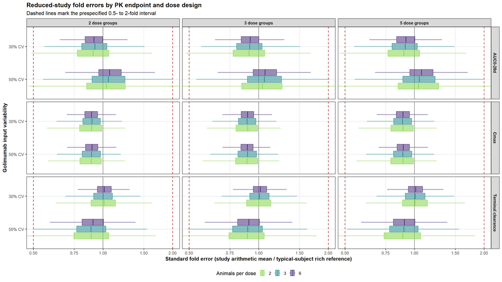

```r
sample_size_colors <- setNames(
  viridisLite::viridis(
    length(ANIMALS_PER_GROUP),
    option = "D",
    direction = -1,
    begin = 0.12,
    end = 0.82
  ),
  ANIMALS_PER_GROUP
)

plot_data <- design_fold_error_replicates |>
  mutate(
    Variability = factor(
      paste0(100 * .data$Variability_CV, "% CV"),
      levels = rev(paste0(100 * VARIABILITY_CV, "% CV"))
    ),
    Animals = factor(.data$N_per_group, levels = ANIMALS_PER_GROUP)
  )

fold_error_plot <- ggplot(
  plot_data,
  aes(
    x = .data$Fold_error,
    y = .data$Variability,
    fill = .data$Animals,
    color = .data$Animals
  )
) +
  geom_vline(xintercept = 1, color = "grey35", linewidth = 0.5) +
  geom_vline(
    xintercept = FOLD_LIMITS,
    color = "#B22222",
    linetype = 2,
    linewidth = 0.7
  ) +
  geom_boxplot(
    width = 0.62,
    outlier.shape = NA,
    alpha = 0.55,
    linewidth = 0.4,
    position = position_dodge2(width = 0.72, preserve = "single")
  ) +
  scale_x_log10(
    breaks = c(0.5, 0.75, 1, 1.5, 2),
    labels = label_number(accuracy = 0.01)
  ) +
  coord_cartesian(xlim = FOLD_LIMITS) +
  scale_fill_manual(values = sample_size_colors) +
  scale_color_manual(values = sample_size_colors) +
  facet_grid(rows = vars(.data$Endpoint), cols = vars(.data$Design)) +
  labs(
    x = paste(
      "Standard fold error",
      "(study arithmetic mean / typical-subject rich reference)"
    ),
    y = "Golimumab input variability",
    fill = "Animals per dose",
    color = "Animals per dose",
    title = "Reduced-study fold errors by PK endpoint and dose design",
    subtitle = "Dashed lines mark the prespecified 0.5- to 2-fold interval"
  ) +
  study_theme

ggsave(
  filename = FOLD_ERROR_FIGURE_FILE,
  plot = fold_error_plot,
  width = 16,
  height = 9,
  dpi = 350,
  bg = "white"
)

fold_error_plot
```

# Step 8 Record the outputs

```r
tibble(
  Output = c(
    "Rich true-model concentration profiles",
    "Rich true-model PK endpoints",
    "Step 1 sparse individual PK endpoints",
    "Reduced-study fold-error replicates",
    "Fold-error summary",
    "Endpoint-level two-fold coverage",
    "Overall two-fold coverage",
    "Fold-error figure"
  ),
  Location = c(
    RICH_PROFILE_FILE,
    REFERENCE_ENDPOINT_FILE,
    SPARSE_ENDPOINT_FILE,
    FOLD_ERROR_REPLICATE_FILE,
    FOLD_ERROR_SUMMARY_FILE,
    ENDPOINT_SUCCESS_FILE,
    OVERALL_SUCCESS_FILE,
    FOLD_ERROR_FIGURE_FILE
  )
) |>
  kable(caption = "Step 2 outputs")
```

Step 2 outputs

| Output | Location |
| --- | --- |
| Rich true-model concentration profiles | C:/Users/krina/Documents/Projects/PBPK_mAb_NAM_Tutorial/03_Study_Simulations/SimsOutputs/Step2_Fold_Error/Tables/golimumab_true_model_rich_profiles.csv |
| Rich true-model PK endpoints | C:/Users/krina/Documents/Projects/PBPK_mAb_NAM_Tutorial/03_Study_Simulations/SimsOutputs/Step2_Fold_Error/Tables/golimumab_true_model_reference_endpoints.csv |
| Step 1 sparse individual PK endpoints | C:/Users/krina/Documents/Projects/PBPK_mAb_NAM_Tutorial/03_Study_Simulations/SimsOutputs/Step2_Fold_Error/Tables/golimumab_step1_sparse_individual_endpoints.csv |
| Reduced-study fold-error replicates | C:/Users/krina/Documents/Projects/PBPK_mAb_NAM_Tutorial/03_Study_Simulations/SimsOutputs/Step2_Fold_Error/Tables/golimumab_reduced_design_fold_error_replicates.csv |
| Fold-error summary | C:/Users/krina/Documents/Projects/PBPK_mAb_NAM_Tutorial/03_Study_Simulations/SimsOutputs/Step2_Fold_Error/Tables/golimumab_reduced_design_fold_error_summary.csv |
| Endpoint-level two-fold coverage | C:/Users/krina/Documents/Projects/PBPK_mAb_NAM_Tutorial/03_Study_Simulations/SimsOutputs/Step2_Fold_Error/Tables/golimumab_reduced_design_endpoint_success.csv |
| Overall two-fold coverage | C:/Users/krina/Documents/Projects/PBPK_mAb_NAM_Tutorial/03_Study_Simulations/SimsOutputs/Step2_Fold_Error/Tables/golimumab_reduced_design_overall_success.csv |
| Fold-error figure | C:/Users/krina/Documents/Projects/PBPK_mAb_NAM_Tutorial/03_Study_Simulations/SimsOutputs/Step2_Fold_Error/Figures/golimumab_reduced_design_fold_error_by_endpoint.png |

```r
clearMemory()
```

# Interpretation checklist

1. Verify that the rich reference contains one nominal typical-subject profile at each of the five doses.
2. Confirm that all sparse profiles link to the physiological body weight used for their terminal-clearance calculation.
3. Interpret a fold error of 1 as agreement with the nominal true-model reference; values below or above 1 indicate under- or overestimation.
4. Compare colors within a variability/design panel to evaluate the effect of animals per dose group.
5. Compare the 30% and 50% rows to evaluate the effect of PBPK input uncertainty.
6. Treat the 0.5- to 2-fold interval as a prespecified tutorial criterion, not a universal decision threshold.
7. Remember that this is a model-based simulation exercise. Treating the nominal Golimumab model as truth does not add new external validation.